# ML Final Project

# *Purpose*

The goal of the project is to predict if people perform a dumbel exercise correct or incorrectly. Based on based on data from accelerometers on the belt, forearm, arm, and dumbell the system is expected to identify the correct execution, or 4 types of faulty executions.

# *Dataset*

The training data set is comprised of 159 features and 19622 samples. The test data set is has 20 samples. The outcome variable is a factor variable named “classe” with levels “A”-“E”, which represents of excersie performance category.

## *Feature Reduction & EDA*

### Extract Raw Sensors’ Data Only

The train set has measurement features of the 3 sensors, and many calculated fields such as “average” “std” that summarise sensor data for a “window” of time. Unfortunately the test set does not include any values for those calculated fields, it would be impossible for any model to predict using those variables. The first feature reduction was to extract only the *sensors’ data features*, and ignore all others. The resulting reduced features is shown in *Figure 1* in the *Appendix* Only 40 features reamained.

```r
# cleaning the data - reducing variables
# creating a table without the calculated fields, only raw measurements

Index <- grepl("^classe|^roll|^pitch|^yaw|^total_|^gyros|^magnet", names(trainRaw))
train <- trainRaw[, Index]
test <- testRaw[, Index]
dim(train)
```

```
## [1] 19622    41
```

### Identify and Remove Correlated Predictors

Next, we computed a correlation matrix and a plot as shown in *Figure 2* in the *Appendix*. There are several highly corrleated features, so we removed them as follows:

```r
train.cor <- cor(train[,-ncol(train)]) # exclude the last variable = "classe"
# remove predictors with corr > 0.7
highlyCor <- findCorrelation(train.cor, 0.70)
train.filtered <- train[,-highlyCor]
dim(train.filtered)
```

```
## [1] 19622    30
```

```r
#remove the same predictors from the test for future use
test.filtered <- test[, -highlyCor]
cat("Number of features in the filtered dataset: ", dim(train.filtered)[2]-1)
```

```
## Number of features in the filtered dataset:  29
```

## *Study Design*

From the training data we sampled 5 folds of “train” and “test” in order to experiment with variuos models and configurations and to select the best model. Since we plan on using also random forest algorithm, it is extremly important to user cross validation, and to run the model on more than one dataset.

```r
# createFolds returns list of indices
set.seed(654913)
folds.train <- createFolds(y=train.filtered$classe, k=5, list=TRUE, returnTrain=TRUE)
folds.test <- createFolds(y=train.filtered$classe, k=5, list=TRUE, returnTrain=FALSE)
```

```
## Number of samples in each training Fold : 15698
```

```
## Number of samples in each testing Fold : 3924
```

## *Model Fitting*

### Random Forest on 1st Fold

We fitted a random forest model as it is considred one of the most accurate algorithms. Then used the model to make prediction on the 1st test fold, and we ran confusionMatrix to check accuracy.

```r
set.seed(43211)
rf1Time <- system.time({
rfFit1<-randomForest(classe ~ ., data = train.filtered[folds.train$Fold1, ], method="rf", prox=TRUE, ntree=500)
})

## predict results with random forest model for 1 test fold
predRF1 <- predict(rfFit1, train.filtered[folds.test$Fold1, ] )

## compare model prediction with test fold
confMat1 <- confusionMatrix(predRF1, train.filtered[folds.test$Fold1, ]$classe)
```

This run has produced *fantastic accuracy* as can be seen in the confustion matrix below:

```
## Confusion Matrix and Statistics
##
##           Reference
## Prediction    A    B    C    D    E
##          A 1116    3    0    0    0
##          B    0  756    1    0    0
##          C    0    0  684    3    0
##          D    0    0    0  640    0
##          E    0    0    0    0  721
##
## Overall Statistics
##
##                Accuracy : 0.9982
##                  95% CI : (0.9963, 0.9993)
##     No Information Rate : 0.2844
##     P-Value [Acc > NIR] : < 2.2e-16
##
##                   Kappa : 0.9977
##  Mcnemar's Test P-Value : NA
##
## Statistics by Class:
##
##                      Class: A Class: B Class: C Class: D Class: E
## Sensitivity            1.0000   0.9960   0.9985   0.9953   1.0000
## Specificity            0.9989   0.9997   0.9991   1.0000   1.0000
## Pos Pred Value         0.9973   0.9987   0.9956   1.0000   1.0000
## Neg Pred Value         1.0000   0.9991   0.9997   0.9991   1.0000
## Prevalence             0.2844   0.1934   0.1746   0.1639   0.1837
## Detection Rate         0.2844   0.1927   0.1743   0.1631   0.1837
## Detection Prevalence   0.2852   0.1929   0.1751   0.1631   0.1837
## Balanced Accuracy      0.9995   0.9979   0.9988   0.9977   1.0000
```

```
## This model run elapsed time is  297.253  seconds.
```

### Random Forest on 2nd and 3rd Folds

In order to validate the random forest model we applied it on 2 more test folds.

```
## Random Forest on 2nd fold has produced the following accuracy:
```

```
##       Accuracy          Kappa  AccuracyLower  AccuracyUpper   AccuracyNull
##      0.9977064      0.9970989      0.9956506      0.9989507      0.2844037
## AccuracyPValue  McnemarPValue
##      0.0000000            NaN
```

```
## Random Forest on 3nd fold has produced the following accuracy:
```

```
##       Accuracy          Kappa  AccuracyLower  AccuracyUpper   AccuracyNull
##      0.9982166      0.9977442      0.9963289      0.9992827      0.2843312
## AccuracyPValue  McnemarPValue
##      0.0000000            NaN
```

### Boosting GBM Algorithm on 4th Fold

While the first model produced excellent results we wanted to experiment with the Boosting algorithm:

```r
gbmTime <- system.time({
gbmFit <-train(classe ~ ., data=train.filtered[folds.train$Fold4, ], method="gbm", verbose = FALSE)
})
## predict model results
gbmPred <- predict(gbmFit, train.filtered[folds.test$Fold4, ] )
## compare model prediction with test fold
confMatGbm <- confusionMatrix(gbmPred, train.filtered[folds.test$Fold4, ]$classe)
```

```
## Boosting GBM on 4th fold has produced accuracy of:
```

```
##       Accuracy          Kappa  AccuracyLower  AccuracyUpper   AccuracyNull
##   9.222732e-01   9.016249e-01   9.134502e-01   9.304610e-01   2.844037e-01
## AccuracyPValue  McnemarPValue
##   0.000000e+00   5.825055e-12
```

```
## Boosting GBM on 4th fold elapsed time is:  939.178  seconds.
```

The boosting results were not as good as the random forest, and it took longer time to process.

### Regression Tree Algorithm on 5th Fold

Finally, we applied a simpler and faster regression tree algorithm on the last fold.

```
## Regression Tree model on 5th Fold has produced the following accuracy:
```

```
##       Accuracy          Kappa  AccuracyLower  AccuracyUpper   AccuracyNull
##   5.416561e-01   4.176251e-01   5.259147e-01   5.573354e-01   2.843312e-01
## AccuracyPValue  McnemarPValue
##  2.303266e-249  1.768202e-205
```

```
## Regression Tree model on 5th Fold elapsed time is:  14.059  seconds.
```

Clearly the performance of the regression tree model is not satisfactory!

## *Prediction of Test Set*

The best accuracy was produced by the random forest model. Hence, we’ll run it on the original test data:

```r
predict.test <- predict(rfFit1, test.filtered)
answers <- as.character(predict.test)
cat("The prediction of classes to test set is:\n", answers,"\n")
```

```
## The prediction of classes to test set is:
##  B A B A A E D B A A B C B A E E A B B B
```

These predictions were uploaded to the course assignment system and verified to be 100% correct.

## *Out-of-Sample Error*

The expected error may be caluclated based on the average performance of the runs of random forest on three different validation folds as follows:

```r
AverageAccuracy <- (confMat1$overall[1]+confMat2$overall[1]+confMat3$overall[1])/3
error <- 1 - AverageAccuracy
cat("The expected out sample error is:", error)
```

```
## The expected out sample error is: 0.001953637
```

# Appendix - Graphs and Compute Output

### Figure 1 - Names of Selected Features

After extracting the sensors’ raw data - only 40 features remain :

```r
names(train)
```

```
##  [1] "roll_belt"            "pitch_belt"           "yaw_belt"
##  [4] "total_accel_belt"     "gyros_belt_x"         "gyros_belt_y"
##  [7] "gyros_belt_z"         "magnet_belt_x"        "magnet_belt_y"
## [10] "magnet_belt_z"        "roll_arm"             "pitch_arm"
## [13] "yaw_arm"              "total_accel_arm"      "gyros_arm_x"
## [16] "gyros_arm_y"          "gyros_arm_z"          "magnet_arm_x"
## [19] "magnet_arm_y"         "magnet_arm_z"         "roll_dumbbell"
## [22] "pitch_dumbbell"       "yaw_dumbbell"         "total_accel_dumbbell"
## [25] "gyros_dumbbell_x"     "gyros_dumbbell_y"     "gyros_dumbbell_z"
## [28] "magnet_dumbbell_x"    "magnet_dumbbell_y"    "magnet_dumbbell_z"
## [31] "roll_forearm"         "pitch_forearm"        "yaw_forearm"
## [34] "total_accel_forearm"  "gyros_forearm_x"      "gyros_forearm_y"
## [37] "gyros_forearm_z"      "magnet_forearm_x"     "magnet_forearm_y"
## [40] "magnet_forearm_z"     "classe"
```

After filtering out the correlated features (>0.7) - only 29 features remain:

```r
names(train.filtered)
```

```
##  [1] "total_accel_belt"     "gyros_belt_x"         "gyros_belt_y"
##  [4] "gyros_belt_z"         "magnet_belt_x"        "magnet_belt_y"
##  [7] "roll_arm"             "pitch_arm"            "yaw_arm"
## [10] "total_accel_arm"      "gyros_arm_y"          "gyros_arm_z"
## [13] "magnet_arm_x"         "magnet_arm_z"         "roll_dumbbell"
## [16] "pitch_dumbbell"       "yaw_dumbbell"         "total_accel_dumbbell"
## [19] "gyros_dumbbell_x"     "gyros_dumbbell_y"     "magnet_dumbbell_z"
## [22] "roll_forearm"         "pitch_forearm"        "yaw_forearm"
## [25] "total_accel_forearm"  "gyros_forearm_x"      "magnet_forearm_x"
## [28] "magnet_forearm_y"     "magnet_forearm_z"     "classe"
```

### Figure 2 - Feature Correlation Matrix

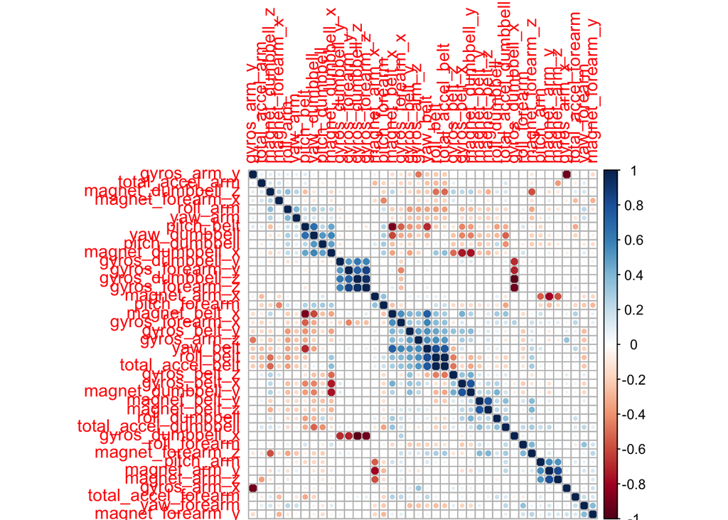

```r
corrplot(train.cor, order = "hclust")  # plot the correlation matrix
```